# Whether Publication date Affected the Length and the theme of Philosophy Schools’Sentences.

## Introduction:

```r
#read the data set
data <- read.csv("/Users/jiaxifang/Desktop/Applied Data Science/philosophy_data.csv")
```

```r
library(dplyr)
library(tm)
library(tm)
library(tidytext)
```

```r
library(dplyr)
library(ggplot2)
library(wordcloud)
```

Before thinking what I want to analyze in this data set, I want to have a basic view about what this data set have.

```r
count_of_school_author<-data %>%
  select(school,author)%>%
  group_by(school,author)%>%
  count%>%
  arrange(school,author)
count_of_school_author
```

```
## # A tibble: 36 × 3
## # Groups:   school, author [36]
##    school     author           n
##    <chr>      <chr>        <int>
##  1 analytic   Kripke       12479
##  2 analytic   Lewis        13120
##  3 analytic   Moore         3668
##  4 analytic   Popper        4678
##  5 analytic   Quine         7373
##  6 analytic   Russell       5073
##  7 analytic   Wittgenstein  9034
##  8 aristotle  Aristotle    48779
##  9 capitalism Keynes        3411
## 10 capitalism Ricardo       3090
## # … with 26 more rows
```

From the table above, it’s obvious the sentences in the data set came from a large number of authors in different philosophy schools.

Now, I want to know the percentage of sentences that each school have contributed to this data set.

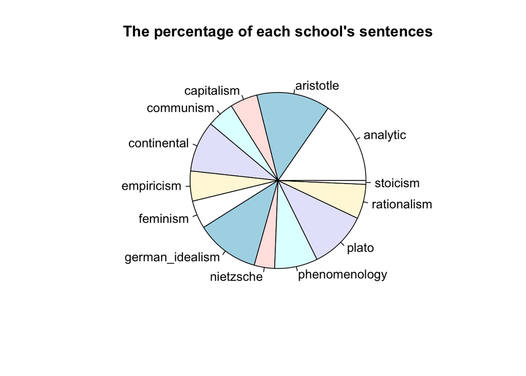

```r
count_of_schools<-count_of_school_author%>%
  group_by(school)%>%
  summarise(count=sum(n))

pie(count_of_schools$count,label=count_of_schools$school,main="The percentage of each school's sentences")
```

Through these pictures, it is obvious the data set record the sentences of different authors from different philosophy schools.

Now I focus on publication date, which I haven’t analyzed yet. In the data set, all sentences have been recorded the publication date. So I’m interested in whether publication date can affect the sentences of philosophy schools.

I have two hypotheses: 1: If the publication date affects the length of sentence? 2: If the publication date affects the theme of sentence?

## Question 1: If the publication date affects the length of sentence?

First of all, I need to divide the whole time period into 3. Because the sentences published before 1650 were not so many, The first time period is before 1650. After 1650, there are a large number of new philosophy sentences, so I divide it into two time period by 1850.

```r
publish_date_1 <- data %>%
  filter(original_publication_date < 1650)

publish_date_2 <- data %>%
  filter((original_publication_date >= 1650) &
           (original_publication_date < 1850))

publish_date_3 <- data %>%
  filter(original_publication_date >=1850)
```

Secondly, I need to get the relationship between length and date.

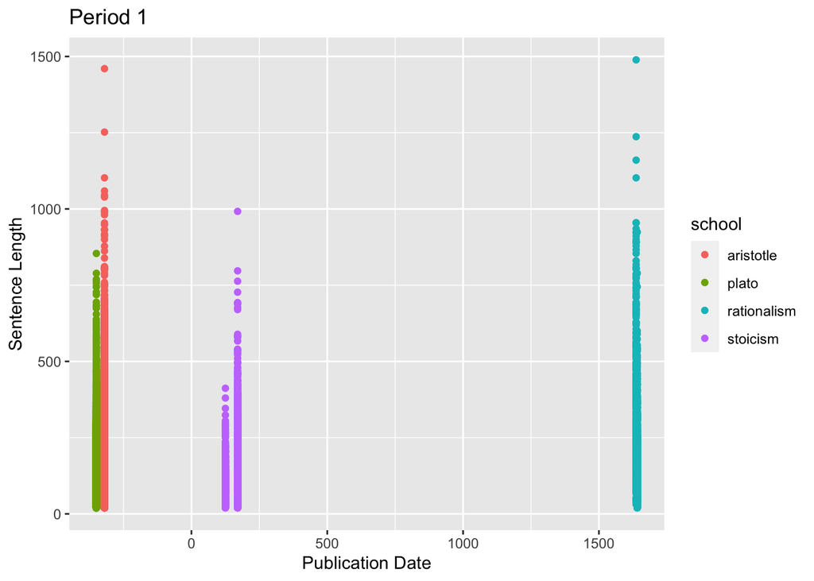

```r
#For period before 1650
ggplot(publish_date_1,aes(original_publication_date,color=school))+geom_point(aes(y=sentence_length,fill=school),stat = "identity")+labs(x="Publication Date",y="Sentence Length",title="Period 1")
```

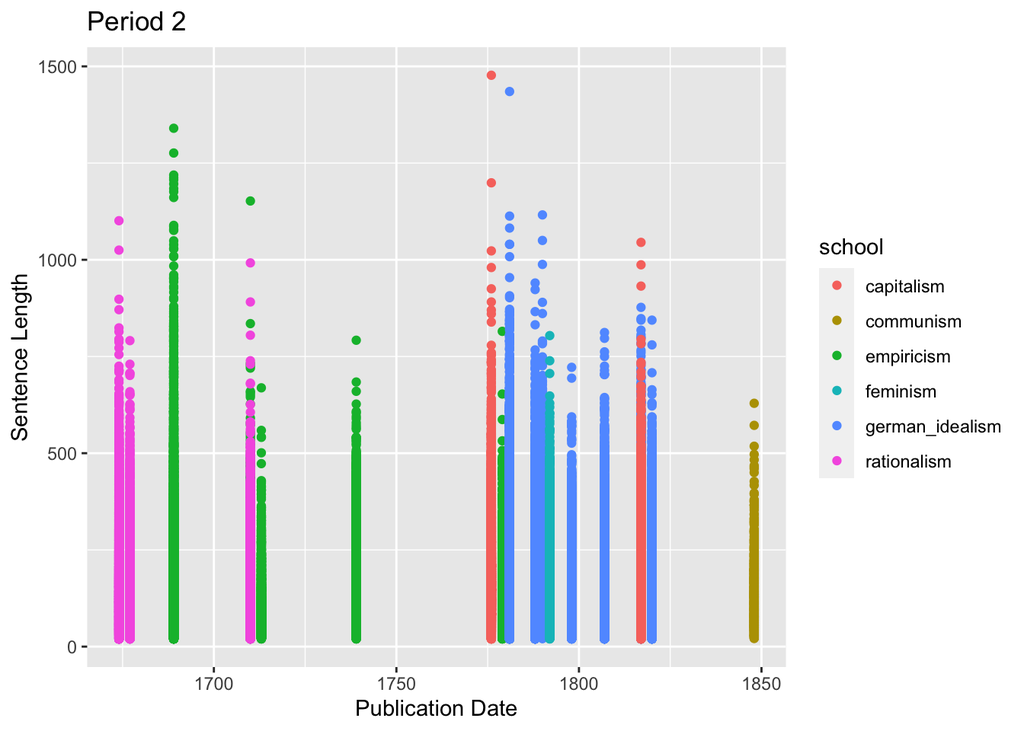

```r
#For period after 1650 and before 1850
ggplot(publish_date_2,aes(original_publication_date,color=school))+geom_point(aes(y=sentence_length,fill=school),stat = "identity")+labs(x="Publication Date",y="Sentence Length",title="Period 2")
```

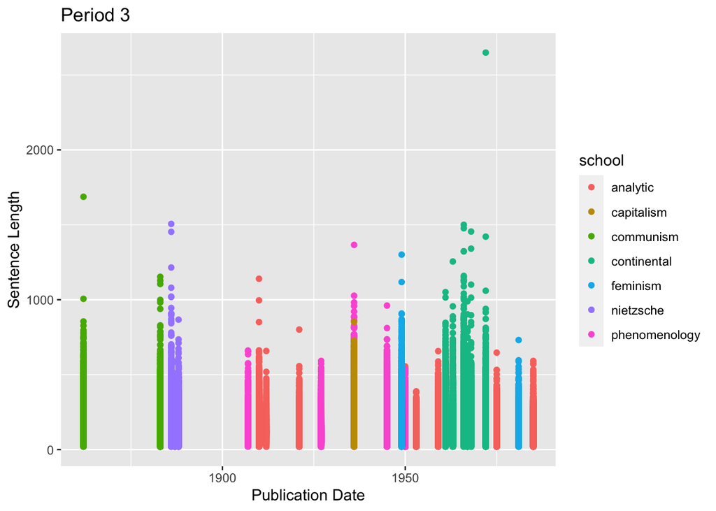

```r
#For period after 1850
ggplot(publish_date_3,aes(original_publication_date,color=school))+geom_point(aes(y=sentence_length,fill=school),stat = "identity")+labs(x="Publication Date",y="Sentence Length",title="Period 3")
```

To check if the result is accurate enough, I need to check the variance and mean values of sentences lengths in different periods.

```r
print(paste0("The variance and mean value of sentences in period 1 is"," ",var(publish_date_1$sentence_length)," ","and"," ",mean(publish_date_1$sentence_length)))
```

```
## [1] "The variance and mean value of sentences in period 1 is 8866.723756051 and 137.771946438797"
```

```r
print(paste0("The variance and mean value of sentences in period 2 is"," ",var(publish_date_2$sentence_length)," ","and"," ",mean(publish_date_2$sentence_length)))
```

```
## [1] "The variance and mean value of sentences in period 2 is 13377.0054896706 and 177.378267580295"
```

```r
print(paste0("The variance and mean value of sentences in period 3 is"," ",var(publish_date_3$sentence_length)," ","and"," ",mean(publish_date_3$sentence_length)))
```

```
## [1] "The variance and mean value of sentences in period 3 is 10087.5015381696 and 141.74545540983"
```

So based on the pictures and calculation results above, we can see the mean value of lengths is close in period 1 and period 3.The mean value is a bit more different in period 2. The variance before 1650 is smaller than that in other two periods, and the variance between 1650 and 1850 is the largest.

## Question 2: If the publication date affects the theme of sentence?

Firstly, I need to get the frequencies of each word in different periods.

For the period before 1650

```r
text_period_1<-Corpus(VectorSource(publish_date_1$sentence_lowered))%>%
  tm_map(removeWords,stopwords(""))%>%
  tm_map(removeWords,character(0))%>%
  tm_map(removePunctuation)%>%
  tm_map(stripWhitespace)
word_Matrix1<- TermDocumentMatrix(text_period_1)%>%
  removeSparseTerms(sparse=0.99)%>%
  tidy()
word_Matrix1_Final<-summarise(group_by(word_Matrix1,term),sum(count))
word_Matrix1_Final2<-word_Matrix1_Final%>%
  mutate(perc=`sum(count)`/sum(`sum(count)`))%>%
  arrange(desc(perc))
head(word_Matrix1_Final2,100)
```

```
## # A tibble: 100 × 3
##    term   `sum(count)`   perc
##    <chr>         <dbl>  <dbl>
##  1 one           14760 0.0446
##  2 will           8857 0.0268
##  3 things         8209 0.0248
##  4 must           7016 0.0212
##  5 man            6407 0.0194
##  6 also           5754 0.0174
##  7 good           5115 0.0155
##  8 now            5010 0.0151
##  9 say            4851 0.0147
## 10 thing          4746 0.0143
## # … with 90 more rows
```

Through the code above, I have got the the percentage of each word, now I want to visualize the result.

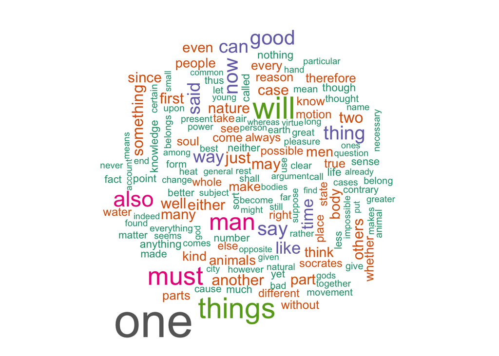

```r
wordcloud(word_Matrix1_Final$term,word_Matrix1_Final$`sum(count)`,min.freq=200,col=brewer.pal(12,"Dark2"),rot.per=0.1)
```

Through the picture, it is obvious the words such as “nature”, “animal”, “reason”, “soul”, and “people” have relatively high frequency in all nouns. Common words like “one”, “will”, and “also” are skipped. These high frequency nouns represents the themes of philosophy schools before 1650.

Now, I need to repeat this step for other two periods.

For the period after 1650 and before 1850.

```r
text_period_2<-Corpus(VectorSource(publish_date_2$sentence_lowered))%>%
  tm_map(removeWords,stopwords(""))%>%
  tm_map(removeWords,character(0))%>%
  tm_map(removePunctuation)%>%
  tm_map(stripWhitespace)
word_Matrix2<- TermDocumentMatrix(text_period_2)%>%
  removeSparseTerms(sparse=0.99)%>%
  tidy()
word_Matrix2_Final<-summarise(group_by(word_Matrix2,term),sum(count))
word_Matrix2_Final2<-word_Matrix2_Final%>%
  mutate(perc=`sum(count)`/sum(`sum(count)`))%>%
  arrange(desc(perc))
head(word_Matrix2_Final2,100)
```

```
## # A tibble: 100 × 3
##    term      `sum(count)`    perc
##    <chr>            <dbl>   <dbl>
##  1 one              14188 0.0260
##  2 can              10356 0.0190
##  3 will              9668 0.0177
##  4 must              7210 0.0132
##  5 may               6411 0.0117
##  6 reason            6394 0.0117
##  7 nature            6282 0.0115
##  8 therefore         6252 0.0114
##  9 things            5128 0.00939
## 10 first             5009 0.00917
## # … with 90 more rows
```

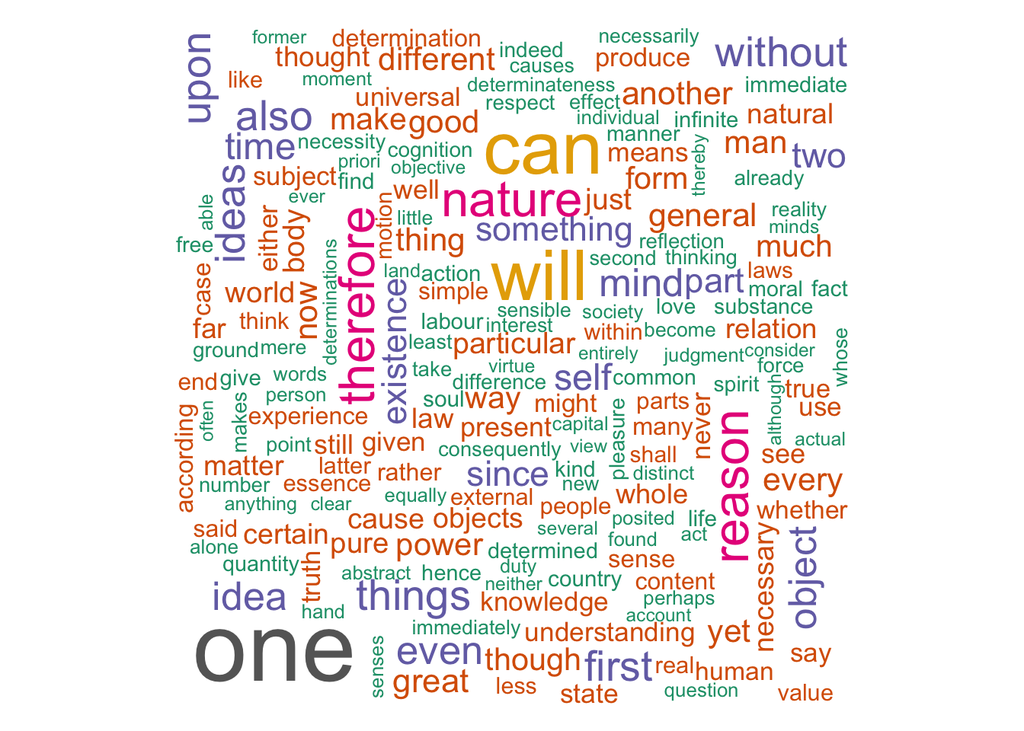

```r
wordcloud(word_Matrix2_Final$term,word_Matrix2_Final$`sum(count)`,min.freq=200,col=brewer.pal(12,"Dark2"),rot.per=0.1)
```

For the period 3

```r
text_period_3<-Corpus(VectorSource(publish_date_3$sentence_lowered))%>%
  tm_map(removeWords,stopwords(""))%>%
  tm_map(removeWords,character(0))%>%
  tm_map(removePunctuation)%>%
  tm_map(stripWhitespace)
word_Matrix3<- TermDocumentMatrix(text_period_3)%>%
  removeSparseTerms(sparse=0.99)%>%
  tidy()
word_Matrix3_Final<-summarise(group_by(word_Matrix3,term),sum(count))
word_Matrix3_Final2<-word_Matrix3_Final%>%
  mutate(perc=`sum(count)`/sum(`sum(count)`))%>%
  arrange(desc(perc))
head(word_Matrix3_Final2,100)
```

```
## # A tibble: 100 × 3
##    term  `sum(count)`   perc
##    <chr>        <dbl>  <dbl>
##  1 one          17591 0.0380
##  2 can          11855 0.0256
##  3 will          9356 0.0202
##  4 world         8507 0.0184
##  5 time          7298 0.0158
##  6 must          6911 0.0149
##  7 even          6846 0.0148
##  8 may           6523 0.0141
##  9 also          6055 0.0131
## 10 first         5628 0.0122
## # … with 90 more rows
```

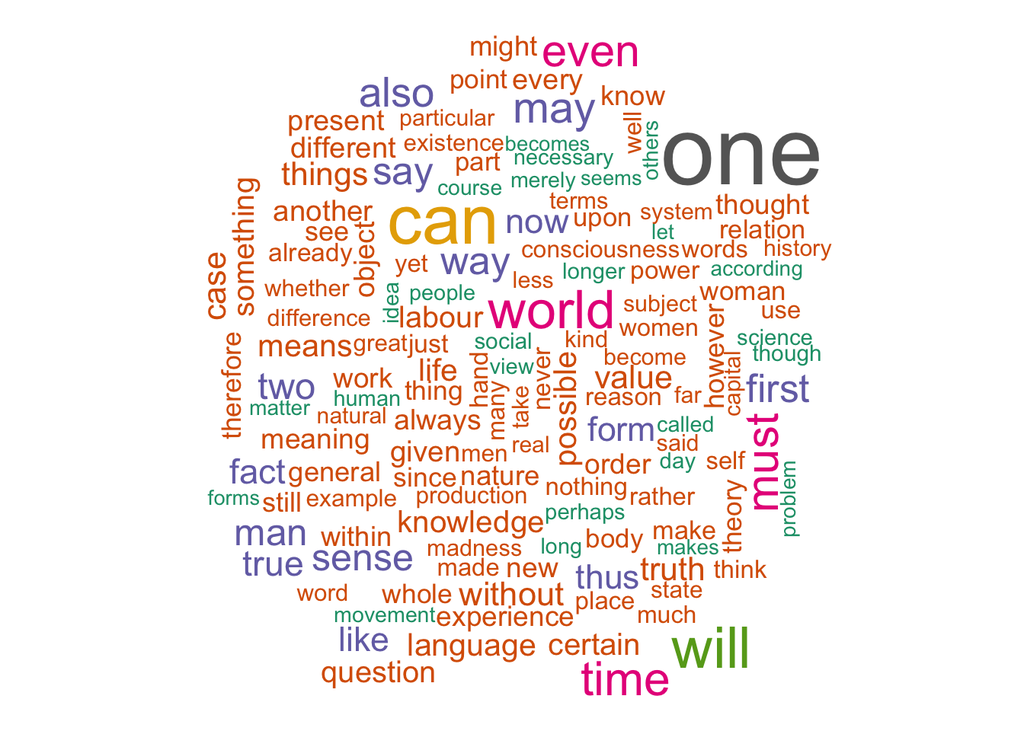

```r
wordcloud(word_Matrix3_Final$term,word_Matrix3_Final$`sum(count)`,min.freq=200,col=brewer.pal(12,"Dark2"),rot.per=0.1)
```

Through the picture above, there are high frequency nouns including “fact”, “nature”, “world”, “language”, and “truth”.

By the pictures, I can have a basic view to the high frequency words in 3 periods.There are a lot of words repeatedly appearing in three periods.

Secondly, to accurately check if the themes of these sentences have been changed by time, I need to select 8 nouns from period 1 and track if their percentages got be fluctuated.

```r
nouns_1<-subset(word_Matrix1_Final2,perc>0.005)
print(nouns_1,50)
```

```
## # A tibble: 73 × 3
##    term   `sum(count)`   perc
##    <chr>         <dbl>  <dbl>
##  1 one           14760 0.0446
##  2 will           8857 0.0268
##  3 things         8209 0.0248
##  4 must           7016 0.0212
##  5 man            6407 0.0194
##  6 also           5754 0.0174
##  7 good           5115 0.0155
##  8 now            5010 0.0151
##  9 say            4851 0.0147
## 10 thing          4746 0.0143
## # … with 63 more rows
```

In the table above, I choose “nature”, “body”, “men”, “animals”, “people”, “reason”, “soul”, “motion”. Now I need to check the percentage change of these nouns.

```r
nouns_selected<-c("nature", "body", "men", "animals", "people", "reason", "soul", "motion")
nouns_perc1<-word_Matrix1_Final2%>%
  filter(term%in%nouns_selected)%>%
  mutate(period="One")
print(nouns_perc1)
```

```
## # A tibble: 8 × 4
##   term    `sum(count)`    perc period
##   <chr>          <dbl>   <dbl> <chr>
## 1 nature          3144 0.00950 One
## 2 body            2946 0.00890 One
## 3 men             2876 0.00869 One
## 4 animals         2703 0.00817 One
## 5 people          2678 0.00809 One
## 6 reason          2280 0.00689 One
## 7 soul            2227 0.00673 One
## 8 motion          2147 0.00649 One
```

For the selected words in perido 2:

```r
nouns_perc2<-word_Matrix2_Final2%>%
  filter(term%in%nouns_selected)%>%
  mutate(period="Two")
print(nouns_perc2)
```

```
## # A tibble: 7 × 4
##   term   `sum(count)`    perc period
##   <chr>         <dbl>   <dbl> <chr>
## 1 reason         6394 0.0117  Two
## 2 nature         6282 0.0115  Two
## 3 men            3135 0.00574 Two
## 4 body           2978 0.00545 Two
## 5 people         1941 0.00355 Two
## 6 motion         1780 0.00326 Two
## 7 soul           1770 0.00324 Two
```

For period 3:

```r
nouns_perc3<-word_Matrix3_Final2%>%
  filter(term%in%nouns_selected)%>%
  mutate(period="Three")
print(nouns_perc3)
```

```
## # A tibble: 5 × 4
##   term   `sum(count)`    perc period
##   <chr>         <dbl>   <dbl> <chr>
## 1 nature         3246 0.00702 Three
## 2 body           2995 0.00647 Three
## 3 reason         2682 0.00580 Three
## 4 men            2487 0.00538 Three
## 5 people         2030 0.00439 Three
```

Now, I need to visualize the result.

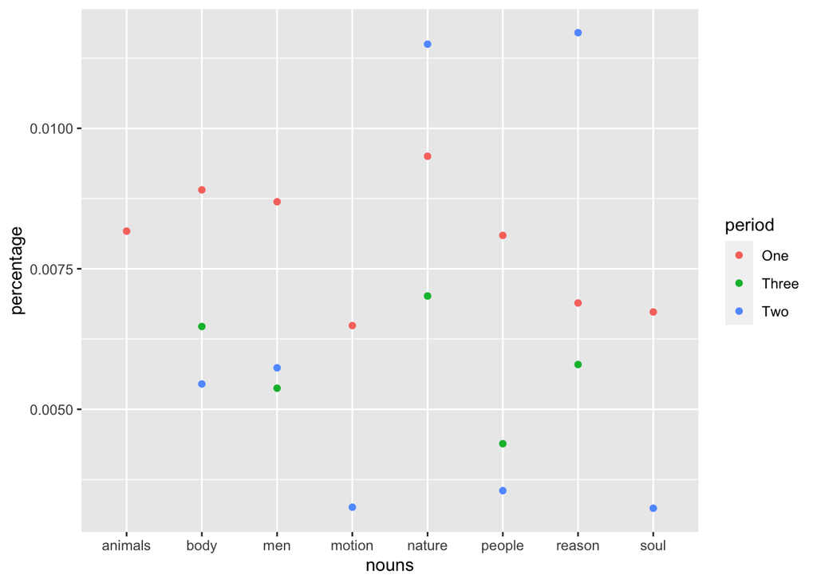

```r
rbind(nouns_perc1,nouns_perc2,nouns_perc3)%>%
  ggplot(aes(term,color=period))+geom_point(aes(y=`perc`,fill=period),stat = "identity")+labs(x="nouns",y="percentage")
```

Conclusively, the percentage change of each noun is large. So we can conclude the time change can cause the change of the theme in philosophy schools’ sentences.

### Conclusion: Through the analysis above, it is obvious that publication date plays an important role in the sentences of philosophy schools. With time change, the lengths and themes of these sentences can vary largely. The reason might caused by the change of society, but it still need more evidence as support.